# RNA-Seq Data Analysis with R

Selda Akdal

2026-04-13

# RNA-Seq Data Analysis with R

## Installing and Loading Packages

### Install required packages

```r
#if (!require("BiocManager", quietly = TRUE))
#  install.packages("BiocManager")

#BiocManager::install("TCGAbiolinks")

# TCGAbiolinks is installed from Bioconductor because it is not available on CRAN.

#if (!require("BiocManager", quietly = TRUE))
#  install.packages("BiocManager")

#BiocManager::install("DESeq2")

# DESeq2 is installed from Bioconductor because it is not available on CRAN.

#install.packages("dplyr")
#install.packages("pheatmap")
```

### Load required libraries

```r
library(TCGAbiolinks)
library(DESeq2)
library(dplyr)
```

```r
library(pheatmap)
```

## Exploring TCGA-LIHC Project Information

```r
TCGAbiolinks::getProjectSummary("TCGA-LIHC")
```

```
## $file_count
## [1] 23930
##
## $data_categories
##    file_count case_count                data_category
## 1        7326        377  Simple Nucleotide Variation
## 2        3226        377             Sequencing Reads
## 3        1634        377                  Biospecimen
## 4         803        377                     Clinical
## 5        4877        377        Copy Number Variation
## 6        1698        376      Transcriptome Profiling
## 7        1290        377              DNA Methylation
## 8         184        184           Proteome Profiling
## 9         949        304 Somatic Structural Variation
## 10       1943        374         Structural Variation
##
## $case_count
## [1] 377
##
## $file_size
## [1] 2.341188e+14
```

Retrieve summary information about the TCGA-LIHC project.

## Querying, Downloading, and Preparing RNA-Seq Data

### Query RNA-Seq Data

GDCquery() is used to query RNA-seq data from the GDC portal.

```r
query_TCGA = GDCquery(
  project = "TCGA-LIHC",
  data.category = "Transcriptome Profiling", # parameter enforced by GDCquery
  data.type = "Gene Expression Quantification",
  workflow.type = "STAR - Counts")
```

```
## o GDCquery: Searching in GDC database
```

```
## Genome of reference: hg38
```

```
## oo Accessing GDC. This might take a while...
```

```
## ooo Project: TCGA-LIHC
```

```
## oo Filtering results
```

```
## ooo By data.type
```

```
## ooo By workflow.type
```

```
## oo Checking data
```

```
## ooo Checking if there are duplicated cases
```

```
## ooo Checking if there are results for the query
```

```
## o Preparing output
```

Retrieve query results.

```r
lihc_res = getResults(query_TCGA)
```

Display column names of the query results.

```r
colnames(lihc_res)
```

```
##  [1] "id"                        "data_format"
##  [3] "cases"                     "access"
##  [5] "file_name"                 "submitter_id"
##  [7] "data_category"             "type"
##  [9] "platform"                  "file_size"
## [11] "created_datetime"          "md5sum"
## [13] "updated_datetime"          "file_id"
## [15] "data_type"                 "state"
## [17] "experimental_strategy"     "version"
## [19] "data_release"              "project"
## [21] "analysis_id"               "analysis_state"
## [23] "analysis_submitter_id"     "analysis_workflow_link"
## [25] "analysis_workflow_type"    "analysis_workflow_version"
## [27] "sample_type"               "is_ffpe"
## [29] "cases.submitter_id"        "sample.submitter_id"
```

Check available sample types.

```r
unique(lihc_res$sample_type)
```

```
## [1] "Primary Tumor"       "Solid Tissue Normal" "Recurrent Tumor"
```

Summarize sample types in the dataset.

```r
table(lihc_res$sample_type)
```

```
##
##       Primary Tumor     Recurrent Tumor Solid Tissue Normal
##                 371                   3                  50
```

Re-query using only primary tumor and normal tissue samples.

```r
query_TCGA = GDCquery(
  project = "TCGA-LIHC",
  data.category = "Transcriptome Profiling", # parameter enforced by GDCquery
  data.type = "Gene Expression Quantification",
  workflow.type = "STAR - Counts",
  sample.type = c("Primary Tumor", "Solid Tissue Normal"))
```

```
## o GDCquery: Searching in GDC database
```

```
## Genome of reference: hg38
```

```
## oo Accessing GDC. This might take a while...
```

```
## ooo Project: TCGA-LIHC
```

```
## oo Filtering results
```

```
## ooo By data.type
```

```
## ooo By workflow.type
```

```
## ooo By sample.type
```

```
## oo Checking data
```

```
## ooo Checking if there are duplicated cases
```

```
## ooo Checking if there are results for the query
```

```
## o Preparing output
```

### Download RNA-Seq Data

Download queried RNA-seq data.

```r
GDCdownload(query = query_TCGA)
```

```
## Of the 421 files for download 421 already exist.
```

```
## All samples have been already downloaded
```

### Prepare RNA-Seq Data

Prepare and load downloaded RNA-seq data.

```r
tcga_data = GDCprepare(query_TCGA)
```

```
## Starting to add information to samples
```

```
##  => Add clinical information to samples
```

```
##  => Adding TCGA molecular information from marker papers
```

```
##  => Information will have prefix 'paper_'
```

```
## Available assays in SummarizedExperiment :
##   => unstranded
##   => stranded_first
##   => stranded_second
##   => tpm_unstrand
##   => fpkm_unstrand
##   => fpkm_uq_unstrand
```

Check dimensions of the prepared dataset.

```r
dim(tcga_data)
```

```
## [1] 60660   421
```

### Count Data (Gene Expression Matrix)

Extract count matrix from the prepared dataset.

```r
count_data <- as.data.frame(assay(tcga_data))
```

Check dimensions of count data.

```r
dim(count_data)
```

```
## [1] 60660   421
```

### Sample Information

Extract clinical/sample metadata.

```r
sample_info <- as.data.frame(colData(tcga_data))
```

Check survival status distribution.

```r
table(sample_info$vital_status)
```

```
##
## Alive  Dead
##   257   164
```

Check gender distribution.

```r
table(sample_info$gender)
```

```
##
## female   male
##    143    278
```

Check race distribution.

```r
table(sample_info$race)
```

```
##
## american indian or alaska native                            asian
##                                2                              164
##        black or african american                     not reported
##                               24                                9
##                          Unknown                            white
##                                4                              218
```

### Gene Annotation Information

Extract gene annotation information.

```r
gene_mapping <- as.data.frame(rowData(tcga_data))
```

Display the first six gene annotations.

```r
head(gene_mapping)
```

```
##                    source type score phase            gene_id      gene_type
## ENSG00000000003.15 HAVANA gene    NA    NA ENSG00000000003.15 protein_coding
## ENSG00000000005.6  HAVANA gene    NA    NA  ENSG00000000005.6 protein_coding
## ENSG00000000419.13 HAVANA gene    NA    NA ENSG00000000419.13 protein_coding
## ENSG00000000457.14 HAVANA gene    NA    NA ENSG00000000457.14 protein_coding
## ENSG00000000460.17 HAVANA gene    NA    NA ENSG00000000460.17 protein_coding
## ENSG00000000938.13 HAVANA gene    NA    NA ENSG00000000938.13 protein_coding
##                    gene_name level    hgnc_id          havana_gene
## ENSG00000000003.15    TSPAN6     2 HGNC:11858 OTTHUMG00000022002.2
## ENSG00000000005.6       TNMD     2 HGNC:17757 OTTHUMG00000022001.2
## ENSG00000000419.13      DPM1     2  HGNC:3005 OTTHUMG00000032742.2
## ENSG00000000457.14     SCYL3     2 HGNC:19285 OTTHUMG00000035941.6
## ENSG00000000460.17  C1orf112     2 HGNC:25565 OTTHUMG00000035821.9
## ENSG00000000938.13       FGR     2  HGNC:3697 OTTHUMG00000003516.3
```

## Differential Expression Analysis with DESeq2

### Preparing DESeq2 Object

Check whether sample names match between count data and metadata.

```r
all(colnames(count_data) %in% rownames(sample_info))
```

```
## [1] TRUE
```

Check whether sample names are in the same order.

```r
all(colnames(count_data) == rownames(sample_info))
```

```
## [1] TRUE
```

Match column names and row names if necessary.

```r
match(colnames(count_data), rownames(sample_info))
```

```
##   [1]   1   2   3   4   5   6   7   8   9  10  11  12  13  14  15  16  17  18
##  [19]  19  20  21  22  23  24  25  26  27  28  29  30  31  32  33  34  35  36
##  [37]  37  38  39  40  41  42  43  44  45  46  47  48  49  50  51  52  53  54
##  [55]  55  56  57  58  59  60  61  62  63  64  65  66  67  68  69  70  71  72
##  [73]  73  74  75  76  77  78  79  80  81  82  83  84  85  86  87  88  89  90
##  [91]  91  92  93  94  95  96  97  98  99 100 101 102 103 104 105 106 107 108
## [109] 109 110 111 112 113 114 115 116 117 118 119 120 121 122 123 124 125 126
## [127] 127 128 129 130 131 132 133 134 135 136 137 138 139 140 141 142 143 144
## [145] 145 146 147 148 149 150 151 152 153 154 155 156 157 158 159 160 161 162
## [163] 163 164 165 166 167 168 169 170 171 172 173 174 175 176 177 178 179 180
## [181] 181 182 183 184 185 186 187 188 189 190 191 192 193 194 195 196 197 198
## [199] 199 200 201 202 203 204 205 206 207 208 209 210 211 212 213 214 215 216
## [217] 217 218 219 220 221 222 223 224 225 226 227 228 229 230 231 232 233 234
## [235] 235 236 237 238 239 240 241 242 243 244 245 246 247 248 249 250 251 252
## [253] 253 254 255 256 257 258 259 260 261 262 263 264 265 266 267 268 269 270
## [271] 271 272 273 274 275 276 277 278 279 280 281 282 283 284 285 286 287 288
## [289] 289 290 291 292 293 294 295 296 297 298 299 300 301 302 303 304 305 306
## [307] 307 308 309 310 311 312 313 314 315 316 317 318 319 320 321 322 323 324
## [325] 325 326 327 328 329 330 331 332 333 334 335 336 337 338 339 340 341 342
## [343] 343 344 345 346 347 348 349 350 351 352 353 354 355 356 357 358 359 360
## [361] 361 362 363 364 365 366 367 368 369 370 371 372 373 374 375 376 377 378
## [379] 379 380 381 382 383 384 385 386 387 388 389 390 391 392 393 394 395 396
## [397] 397 398 399 400 401 402 403 404 405 406 407 408 409 410 411 412 413 414
## [415] 415 416 417 418 419 420 421
```

Convert grouping variable into a factor.

```r
sample_info$shortLetterCode <- factor(sample_info$shortLetterCode)
```

### Create DESeqDataSet Object

Create DESeqDataSet object for DESeq2 analysis.

```r
dds <- DESeqDataSetFromMatrix(countData = count_data,
                              colData = sample_info,
                              design = ~shortLetterCode)

dds
```

```
## class: DESeqDataSet
## dim: 60660 421
## metadata(1): version
## assays(1): counts
## rownames(60660): ENSG00000000003.15 ENSG00000000005.6 ...
##   ENSG00000288674.1 ENSG00000288675.1
## rowData names(0):
## colnames(421): TCGA-DD-AACI-01A-11R-A41C-07
##   TCGA-UB-AA0V-01A-11R-A38B-07 ... TCGA-BD-A3EP-11A-12R-A22L-07
##   TCGA-BW-A5NO-01A-11R-A27V-07
## colData names(64): barcode patient ... released sample.aux
```

Filter out low-count genes.

```r
keep <- rowSums(counts(dds)) >= 10
dds <- dds[keep,]
```

Set reference level for comparison.

```r
dds$shortLetterCode <- relevel(dds$shortLetterCode, ref = "NT")
```

## Running Differential Expression Analysis

Run DESeq2 analysis.

```r
dds <- DESeq(dds)
```

```
## -- replacing outliers and refitting for 5128 genes
## -- DESeq argument 'minReplicatesForReplace' = 7
## -- original counts are preserved in counts(dds)
```

Extract DESeq2 results.

```r
DESeq_result <- results(dds)
```

Convert DESeq2 results into a dataframe.

```r
DESeq_result <- as.data.frame(DESeq_result)
head(DESeq_result)
```

```
##                       baseMean log2FoldChange      lfcSE       stat
## ENSG00000000003.15 4982.525016    -0.19115422 0.11517840 -1.6596360
## ENSG00000000005.6     3.377442    -0.97341591 0.36498305 -2.6670167
## ENSG00000000419.13 1208.066394     0.01937042 0.06675665  0.2901646
## ENSG00000000457.14  538.738147     0.06098645 0.08170998  0.7463769
## ENSG00000000460.17  253.240048     0.89444020 0.16049781  5.5729122
## ENSG00000000938.13  244.143068    -0.86991939 0.15944986 -5.4557551
##                          pvalue         padj
## ENSG00000000003.15 9.698771e-02 1.384605e-01
## ENSG00000000005.6  7.652786e-03 1.444933e-02
## ENSG00000000419.13 7.716903e-01 8.139366e-01
## ENSG00000000457.14 4.554398e-01 5.262130e-01
## ENSG00000000460.17 2.505159e-08 1.183183e-07
## ENSG00000000938.13 4.876515e-08 2.206956e-07
```

Sort results by p-value.

```r
DESeq_result_ordered <- DESeq_result[order(DESeq_result$pvalue),]
head(DESeq_result_ordered)
```

```
##                     baseMean log2FoldChange     lfcSE     stat        pvalue
## ENSG00000187730.9   165.2490       4.453389 0.1939990 22.95574 1.291398e-116
## ENSG00000130300.9  4376.1799       2.900874 0.1382952 20.97596  1.087583e-97
## ENSG00000100526.20  366.2110       3.904301 0.1895479 20.59797  2.861914e-94
## ENSG00000158402.20  193.7189       4.348659 0.2133415 20.38356  2.340156e-92
## ENSG00000077152.11  367.6041       3.194507 0.1572427 20.31577  9.326966e-92
## ENSG00000143228.13  268.5652       4.190042 0.2075319 20.18987  1.201875e-90
##                             padj
## ENSG00000187730.9  4.267037e-112
## ENSG00000130300.9   1.796795e-93
## ENSG00000100526.20  3.152112e-90
## ENSG00000158402.20  1.933085e-88
## ENSG00000077152.11  6.163632e-88
## ENSG00000143228.13  6.618726e-87
```

Filter significantly differentially expressed genes.

```r
filtered <- filter(DESeq_result, padj < 0.05, abs(log2FoldChange) > 1)
```

Separate upregulated and downregulated genes.

```r
up_regulated <- subset(filtered, log2FoldChange > 1)
down_regulated <- subset(filtered, log2FoldChange < -1)
```

Map Ensembl IDs to gene symbols.

```r
filtered_name <- rownames(filtered)
filtered_name <- subset(gene_mapping, gene_id %in% filtered_name, select = gene_name)
```

```r
filtered_up_name <- rownames(up_regulated)
filtered_up_name <- subset(gene_mapping, gene_id %in% filtered_up_name, select = gene_name)
```

Save filtered results to a text file.

```r
write.table(filtered, file = "filtered.txt", sep = "\t",row.names = TRUE)
```

## PCA Plot Generation

Perform variance stabilizing transformation (VST).

```r
vsd <- vst(dds, blind = FALSE)
```

Generate PCA plot using transformed data.

```
## using ntop=500 top features by variance
```

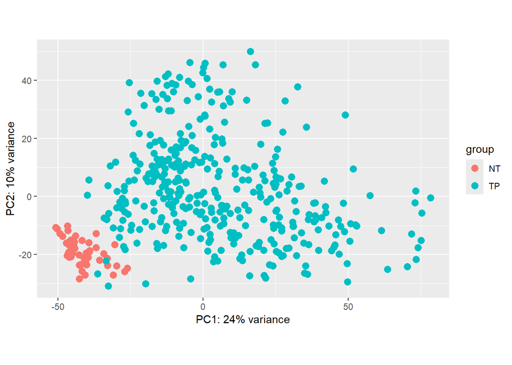

```r
plotPCA(vsd, intgroup = c("shortLetterCode"))
```

## Heatmap Visualization

Select top 10 significant genes.

```r
top_hits <- DESeq_result[order(DESeq_result$padj),][1:10,]
top_hits <- rownames(top_hits)
top_hits
```

```
##  [1] "ENSG00000187730.9"  "ENSG00000130300.9"  "ENSG00000100526.20"
##  [4] "ENSG00000158402.20" "ENSG00000077152.11" "ENSG00000143228.13"
##  [7] "ENSG00000117724.13" "ENSG00000154839.10" "ENSG00000043355.12"
## [10] "ENSG00000135451.13"
```

Retrieve gene symbols for top genes.

```r
top_hits_gename <- subset(gene_mapping, gene_id %in% top_hits, select = gene_name)
```

Match gene names with selected genes.

```r
top_hits_gename <- top_hits_gename[match(top_hits, rownames(top_hits_gename)),]
```

Generate heatmap using normalized expression values.

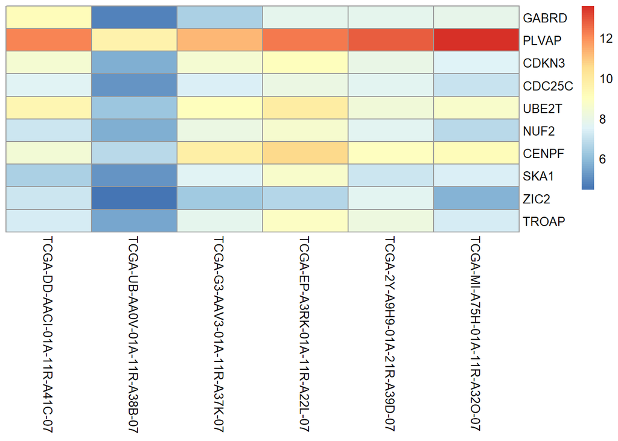

```r
pheatmap(assay(vsd)[top_hits,1:6],cluster_rows = FALSE, show_names=TRUE, cluster_cols=FALSE, labels_row = top_hits_gename)
```

Generate clustered heatmap.

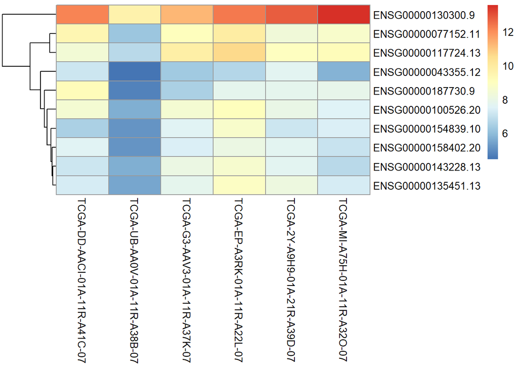

```r
pheatmap(assay(vsd)[top_hits,1:6], cluster_cols = FALSE)
```

Add sample annotations to heatmap.

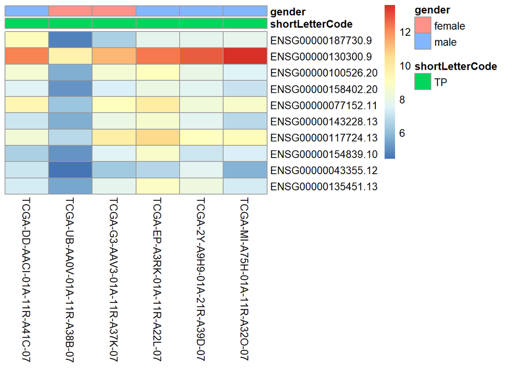

```r
annot_info <- as.data.frame(colData(dds)[,c('shortLetterCode','gender')])

pheatmap(assay(vsd)[top_hits,1:6],cluster_rows = FALSE, show_rownames = TRUE,
         cluster_cols=FALSE, annotation_col = annot_info)
```